# H1 Policy Comparison: Same-Day Release of Unused Reservations

Policies optimized for average appointment utilization

## How the simulations were run

- **840 backgrounds:** 42 anchor settings and 798 Sobol-sampled settings.
- **10 paired seeds** were used for every evaluated policy cell.
- Demand-to-capacity ratio ranged from **0.8 to 3.0**; priority-group share ranged from **0.1 to 0.9**.
- Daily capacity ranged from **20 to 50 slots** and the native horizon ranged from **2 to 26 days**.
- Cancellation, balking, and no-show behavior varied across both groups.
- Paired bootstrap intervals used **2,000 draws**. A difference within **0.005** utilization was treated as a practical tie.

The four policy regimes were:

| Policy | Booking horizon | Priority reservations |
| --- | --- | --- |
| Baseline | Fixed at the background value | None |
| Horizon only | Optimized | None |
| Reservation only | Fixed at the background value | Quantity and reservation window optimized |
| Both flexible | Optimized | Quantity and reservation window optimized |

Class 1 and Class 2 remain different simulated patient populations in every regime. Class 1 is called the **priority group** only when (Q>0). When (Q=0), both groups book through the general first-come-first-served pool.

## Overall policy comparison

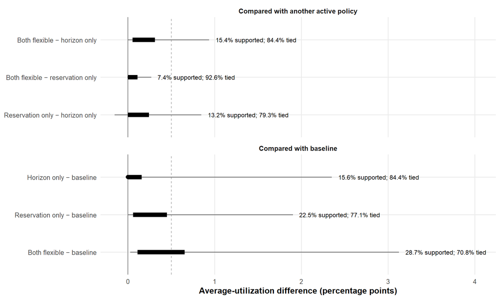

Figure 1: Distribution of average-utilization differences across all six policy comparisons. Points show medians, thick lines show interquartile ranges, and thin lines show the 10th–90th percentiles.

- Both-flexible weakly contains the other policy choices, so it cannot be worse after optimization.
- That does **not** mean both policies are always needed. Most backgrounds are practical ties.
- Reservation-only and horizon-only should be read as competing single-policy options, not as a ranking that applies to every clinic.

| Comparison | Median difference | Supported increase | Practical tie |
| --- | --- | --- | --- |
| Both flexible − baseline | 0.23 pp | 28.7% | 70.8% |
| Both flexible − horizon only | 0.15 pp | 15.4% | 84.4% |
| Both flexible − reservation only | 0.02 pp | 7.4% | 92.6% |
| Horizon only − baseline | 0.00 pp | 15.6% | 84.4% |
| Reservation only − baseline | 0.17 pp | 22.5% | 77.1% |
| Reservation only − horizon only | 0.09 pp | 13.2% | 79.3% |

## Which scenarios benefit?

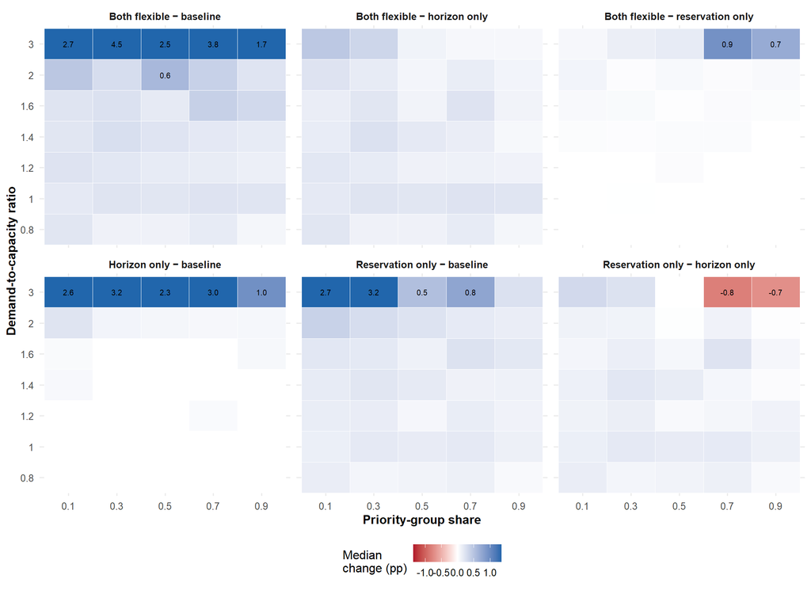

Figure 2: Median average-utilization difference by demand pressure and priority-group share. Values are aggregated over the remaining scenario parameters.

The dominant pattern is demand pressure:

- At low and moderate demand, the policies are usually tied in utilization.
- The clearest gains appear when demand approaches the upper end of the tested range.
- Priority-group share changes which single policy performs better, but it does not create one universal winner.

### No-show behavior and reservation value

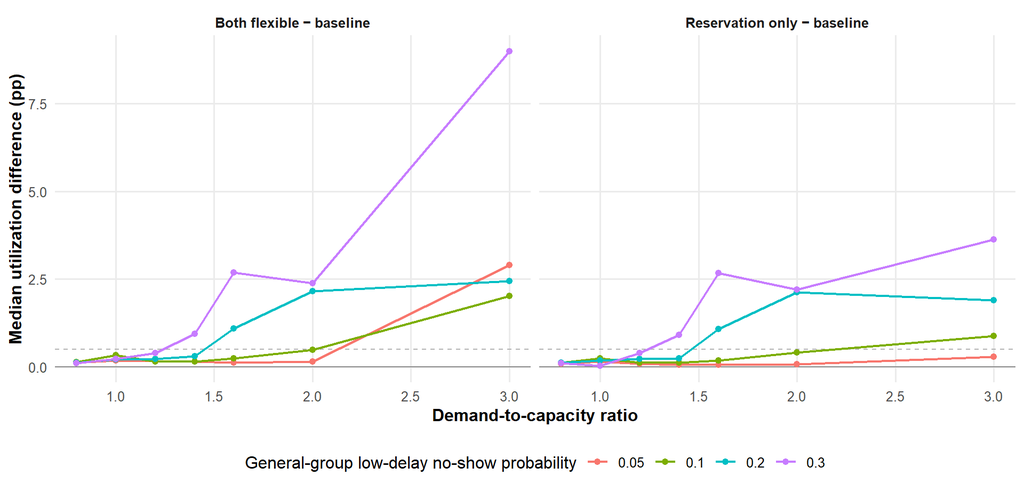

Figure 3: Reservation-related gains rise under heavy demand when the general group has a higher low-delay no-show probability. These are grouped associations across backgrounds, not isolated one-parameter causal effects.

With same-day release:

- Demand remains the strongest separator between ties and meaningful utilization gains.
- Reservations begin to show modest gains across a wider range of priority-group shares because unused reserved slots can be reused.
- At a demand-to-capacity ratio of 3.0, the median reservation-only gain rises from about **0.3 pp** to about **3.6 pp** as the general-group low-delay no-show probability rises from 0.05 to 0.30.
- The incremental value of horizon flexibility after reservations are optimized is usually small: both-flexible and reservation-only tie in most backgrounds.

## Optimized policy parameters

The figure below focuses on **both-flexible**, where the horizon, reserved quantity, and reservation window were jointly selected.

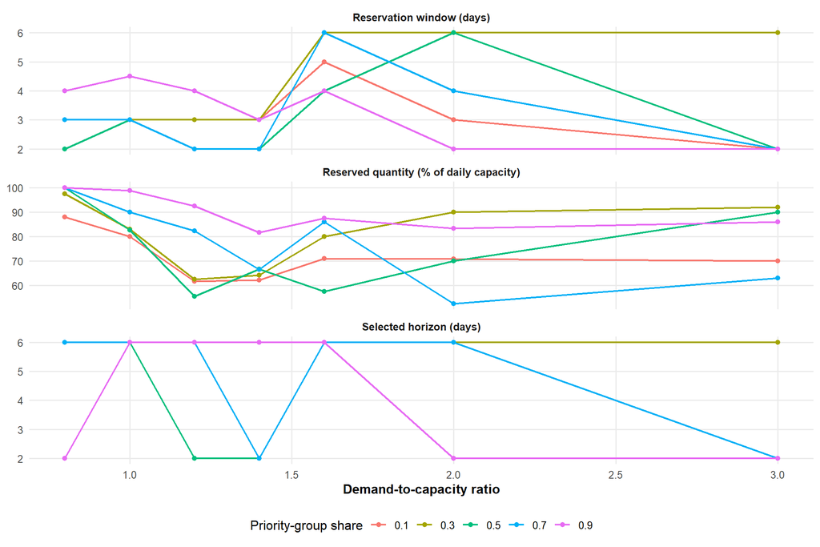

Figure 4: Median jointly optimized policy parameters by demand and priority-group share.

Release changes how the nominal reservation parameters should be interpreted:

- The jointly optimized horizon is **2 days** in 44.5% of backgrounds and **6 days** in 37.4%.
- Optimized (Q) is often large—commonly 75%–90% of daily capacity across priority-group shares.
- A large (Q) does **not** mean that the same share is withheld from the general group for the full day. Unused reservations are released.
- Release therefore makes high nominal reservation caps less costly than under the strict policy.
- Reservation windows are generally longer than under strict reservation when the horizon is fixed, but remain short under many jointly optimized settings.

## Effects on the two patient groups

The utilization objective counts completed appointments, regardless of which group receives them. A utilization gain can therefore coexist with a redistribution of access.

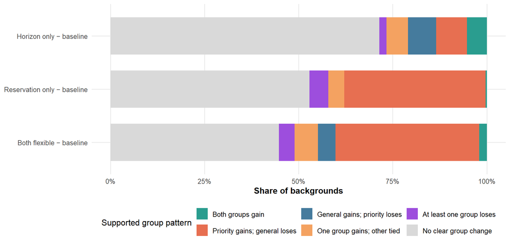

Figure 5: Supported Class 1 and Class 2 served-rate patterns for each policy compared with baseline.

- Horizon changes can help or hurt either group because they change the set of delays offered to everyone.
- Reservations more directly redistribute access toward Class 1.
- “Priority gains; general loses” means the paired confidence intervals support both directions. It is not inferred from point estimates alone.

The main strict-reservation trade-off appears under congested conditions:

- Reservation-only produces a supported priority-gain/general-loss pattern in 37.5% of backgrounds.
- Both-flexible produces the same pattern in 38.2%.
- At demand ratios below 1.2, clear group changes are rare.
- As demand rises, reservations increasingly determine **who** receives limited capacity rather than creating additional capacity.

## Comparison with the twice-weighted Class 1 objective

Class 1 therefore receives **twice the policy weight** of Class 2.

### What is similar?

- The baseline is identical because it has no parameters to optimize.
- Demand remains the main condition under which policy changes matter.
- Short horizons remain common under both objectives.
- Horizon-only is more stable across objectives than reservation policies.

### What changes?

| Policy | Same exact policy cell | Median average-utilization change | Median weighted-rate change | Average-utilization loss > 0.5 pp | Weighted-rate gain > 0.5 pp | Priority gains; general loses |
| --- | --- | --- | --- | --- | --- | --- |
| Both flexible | 11.5% | -0.20 pp | 0.36 pp | 23.5% | 44.0% | 26.7% |
| Horizon only | 71.0% | 0.00 pp | 0.00 pp | 3.8% | 13.0% | 8.5% |
| Reservation only | 21.1% | -0.14 pp | 0.19 pp | 21.2% | 35.8% | 22.0% |

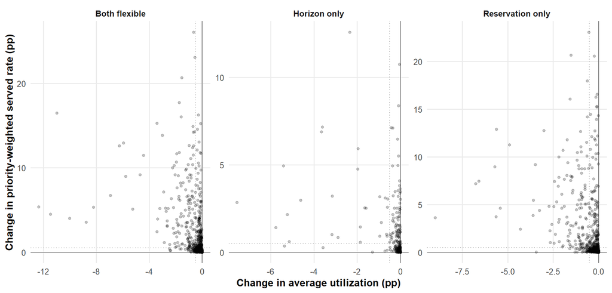

Figure 6: Changing from the average-utilization optimum to the twice-weighted Class 1 optimum. Upper-left observations gain priority-weighted access while losing average utilization.

The weighted objective still changes reservation design, but release softens the capacity cost:

- For reservation-only, switching to the weighted optimum changes average utilization by a median of -0.14 pp and raises the weighted served rate by 0.19 pp.
- For both-flexible, the corresponding medians are -0.20 pp and 0.36 pp.
- Exact reservation cells remain uncommon across objectives, but the median utilization loss is smaller than under strict reservation.
- The largest differences are in (Q), reservation-window length, and Class 1 versus Class 2 access—not in the overall demand pattern.

## Brief comparison with the companion report

The strict-reservation report has the same central result: meaningful utilization gains concentrate under heavy demand.

Compared with strict reservation:

- Release increases the share of backgrounds where reservation-only improves utilization.
- Release supports much larger nominal (Q) values because unused reservations can return to the general pool.
- The twice-weighted Class 1 objective causes a smaller average-utilization loss under release.
- Strict reservation requires more conservative reserved quantities and shorter reservation windows to avoid stranded capacity.

## Conclusions

- **Low and moderate demand:** practical ties remain the dominant result.
- **Heavy demand:** horizon flexibility and reservations can both improve utilization; the largest gains occur when no-show risk is also high.
- **Release effect:** reservation-only performs better relative to horizon-only than under strict reservation, while both-flexible is usually tied with reservation-only.
- **Access distribution:** release protects capacity use but does not eliminate priority-group gains at the general group’s expense.
- **Objective choice matters:** the twice-weighted Class 1 objective changes reservation design, although release reduces its utilization cost.